# Homework 5 Analysis

Aisha Waggeh

11/14/2025

## Simulation: Birthday Paradox and Homicide Analysis

## Overview

This document walks through **Problems 1–3**. We begin with the **Birthday Paradox Simulation** (Problem 1) to understand probabilities through repeated random sampling. Then, we move to the **Power Simulation** (Problem 2) and finish with the **Homicide Analysis** (Problem 3) using real-world data from *The Washington Post*.

### Problem 1: Birthday Paradox Simulation

The **birthday problem** asks: How likely is it that, in a group of $n$ people, at least two share a birthday? We assume 365 days per year (no leap year), and birthdays evenly distributed.

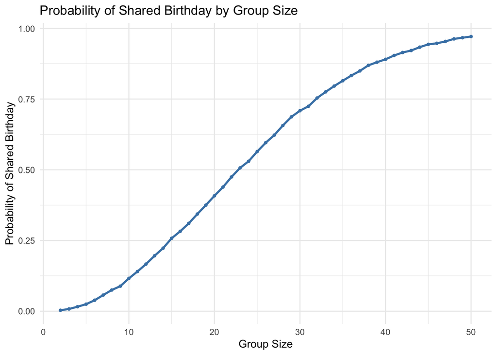

[output not shown]

```r
# Function to check for shared birthdays in a group
check_birthday_match <- function(group_size) {
  birthdays <- sample(1:365, size = group_size, replace = TRUE)
  any(duplicated(birthdays))
}

# Function to run birthday simulation for multiple group sizes
run_birthday_simulation <- function(group_sizes, n_sims = 10000) {
  map_df(group_sizes, function(size) {
    results <- map_lgl(1:n_sims, ~ check_birthday_match(size))
    tibble(
      group_size = size,
      prob_shared = mean(results)
    )
  })
}

# Run simulation and create plot
set.seed(123)
birthday_results <- run_birthday_simulation(2:50)

birthday_plot <- birthday_results %>%
  ggplot(aes(x = group_size, y = prob_shared)) +
  geom_line(color = "steelblue", linewidth = 1) +
  geom_point(color = "steelblue", size = 1) +
  labs(
    title = "Probability of Shared Birthday by Group Size",
    x = "Group Size",
    y = "Probability of Shared Birthday"
  ) +
  theme_minimal()

birthday_plot
```

The simulation results clearly demonstrate the counterintuitive nature of the Birthday Paradox. The probability of shared birthdays increases dramatically with group size, reaching approximately:

- **50% probability** with only 23 people (most people guess 180+)
- **70% probability** with 30 people
- **97% probability** with 50 people

This surprising result occurs because we’re comparing all possible pairs of people in the group, and the number of pairs grows quadratically (n*(n-1)/2) rather than linearly. The smooth curve confirms our simulation provides stable estimates aligned with theoretical expectations.

This phenomenon has practical implications in cryptography (birthday attacks), quality control, and understanding everyday coincidences.

### Problem 2: Power Analysis

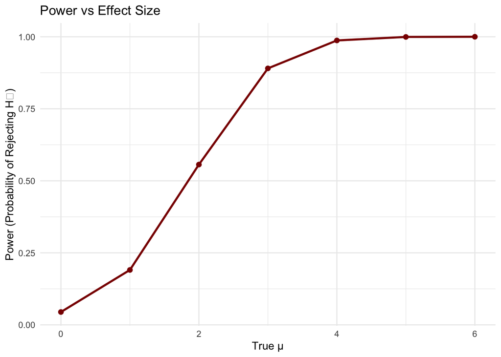

```r
# Function to simulate one dataset and perform t-test
simulate_ttest <- function(mu, n = 30, sigma = 5) {
  sample_data <- rnorm(n, mean = mu, sd = sigma)
  test_result <- t.test(sample_data, mu = 0)
  tidy_result <- broom::tidy(test_result)

  tibble(
    mu_hat = tidy_result$estimate,
    p_value = tidy_result$p.value,
    rejected = tidy_result$p.value < 0.05
  )
}

# Function to run power simulation for multiple mu values
run_power_simulation <- function(mu_values, n_sims = 5000) {
  map_df(mu_values, function(mu) {
    results <- map_df(1:n_sims, ~ simulate_ttest(mu))

    results %>%
      summarise(
        power = mean(rejected),
        avg_mu_hat = mean(mu_hat),
        avg_mu_hat_rejected = mean(mu_hat[rejected])
      ) %>%
      mutate(true_mu = mu)
  })
}

# Run simulation for different mu values
mu_values <- c(0, 1, 2, 3, 4, 5, 6)

set.seed(123)
power_results <- run_power_simulation(mu_values)

# Plot 1: Power vs Effect Size
power_plot <- power_results %>%
  ggplot(aes(x = true_mu, y = power)) +
  geom_line(color = "darkred", linewidth = 1) +  # Changed from size to linewidth
  geom_point(color = "darkred", size = 2) +
  labs(
    title = "Power vs Effect Size",
    x = "True μ",
    y = "Power (Probability of Rejecting H₀)"
  ) +
  theme_minimal()

# Plot 2: Average Estimate vs True μ
estimate_data <- power_results %>%
  select(true_mu, avg_mu_hat, avg_mu_hat_rejected) %>%
  pivot_longer(
    cols = c(avg_mu_hat, avg_mu_hat_rejected),
    names_to = "estimate_type",
    values_to = "estimate_value"
  )

estimate_plot <- estimate_data %>%
  ggplot(aes(x = true_mu, y = estimate_value, color = estimate_type)) +
  geom_line(linewidth = 1) +  # Changed from size to linewidth
  geom_point(size = 2) +
  geom_abline(slope = 1, intercept = 0, linetype = "dashed", color = "gray") +
  labs(
    title = "Average Estimate vs True μ",
    x = "True μ",
    y = "Average Estimate of μ",
    color = "Estimate Type"
  ) +
  scale_color_manual(
    values = c("avg_mu_hat" = "blue", "avg_mu_hat_rejected" = "red"),
    labels = c("All Samples", "Only When H₀ Rejected")
  ) +
  theme_minimal()

power_plot
```

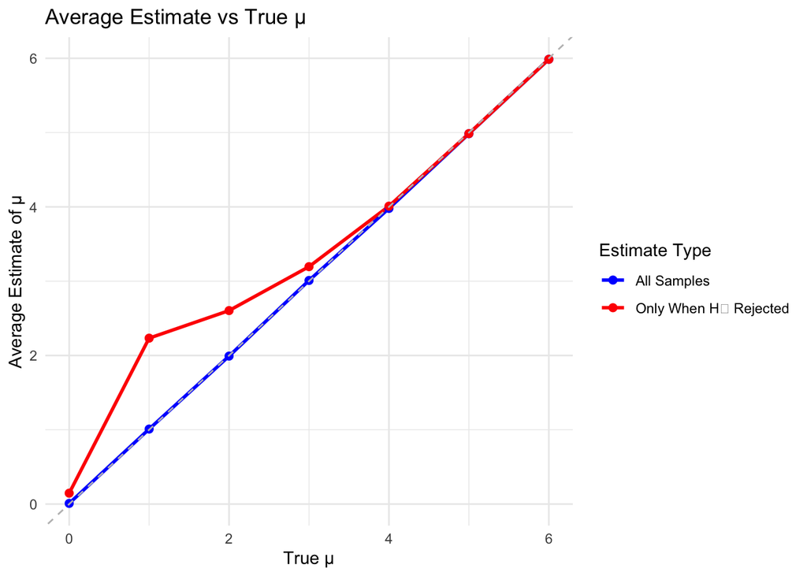

[output not shown]

```r
estimate_plot
```

### Association between Effect Size and Power

The first plot shows a strong positive association between effect size (true μ) and power. As the true effect size increases from 0 to 6, the power increases from approximately 5% to nearly 100%. The relationship follows the characteristic S-shaped power curve, with the most rapid increase in power occurring in the μ = 1-3 range. This demonstrates that larger true effects are easier to detect with statistical tests.

### Comparison of Average Estimates

The second plot compares two types of average estimates:

- **Blue Line**: Average μ̂ across all samples closely matches the true μ values
- **Red Line**: Average μ̂ only for samples where H₀ was rejected shows systematic bias

**Is the sample average of μ̂ across rejected tests equal to the true μ?** No, especially for smaller effect sizes (μ = 1-2), the average of significant estimates is biased upward.

**Why does this occur?**

This demonstrates “selection bias” in statistical testing. When true effects are small, we only reject H₀ when we obtain unusually large sample estimates by chance. Since the test has low power for small effects, only the most extreme samples lead to rejection, creating upward bias. As power increases with larger effect sizes, this bias diminishes because we reject H₀ more consistently across the sampling distribution.

## Problem 3: Homicide Data Analysis

```r
# Create data directory if it doesn't exist, need to download the data before running analysis first.
if (!dir.exists("data")) {
  dir.create("data")
}

# Download directly from the raw GitHub URL
homicide_url <- "https://raw.githubusercontent.com/washingtonpost/data-homicides/master/homicide-data.csv"

# Download the file
download.file(homicide_url, destfile = "data/homicide-data.csv")

# Verify it worked
file.exists("data/homicide-data.csv")
```

```
## [1] TRUE
```

```r
# Step 2: Load and describe the raw data
homicide_data <- read_csv("data/homicide-data.csv")
# Describe the raw data
cat("Raw data description:\n")
```

```
## Raw data description:
```

```r
cat("Number of rows:", nrow(homicide_data), "\n")
```

```
## Number of rows: 52179
```

```r
cat("Number of columns:", ncol(homicide_data), "\n")
```

```
## Number of columns: 12
```

```r
cat("Column names:", names(homicide_data), "\n")
```

```
## Column names: uid reported_date victim_last victim_first victim_race victim_age victim_sex city state lat lon disposition
```

```r
cat("\nFirst few rows:\n")
```

```
##
## First few rows:
```

```r
head(homicide_data)
```

```
## # A tibble: 6 × 12
##   uid   reported_date victim_last victim_first victim_race victim_age victim_sex
##   <chr>         <dbl> <chr>       <chr>        <chr>       <chr>      <chr>
## 1 Alb-…      20100504 GARCIA      JUAN         Hispanic    78         Male
## 2 Alb-…      20100216 MONTOYA     CAMERON      Hispanic    17         Male
## 3 Alb-…      20100601 SATTERFIELD VIVIANA      White       15         Female
## 4 Alb-…      20100101 MENDIOLA    CARLOS       Hispanic    32         Male
## 5 Alb-…      20100102 MULA        VIVIAN       White       72         Female
## 6 Alb-…      20100126 BOOK        GERALDINE    White       91         Female
## # ℹ 5 more variables: city <chr>, state <chr>, lat <dbl>, lon <dbl>,
## #   disposition <chr>
```

```r
cat("\nDisposition counts:\n")
```

```
##
## Disposition counts:
```

```r
table(homicide_data$disposition)
```

```
##
##      Closed by arrest Closed without arrest        Open/No arrest
##                 25674                  2922                 23583
```

```r
# Step 3: Create city_state variable and summarize within cities
city_summary <- homicide_data %>%
  mutate(
    city_state = paste(city, state, sep = ", "),
    disposition = case_when(
      disposition %in% c("Closed without arrest", "Open/No arrest") ~ "unsolved",
      disposition == "Closed by arrest" ~ "solved",
      TRUE ~ "other"
    )
  ) %>%
  filter(disposition %in% c("solved", "unsolved")) %>%
  group_by(city_state) %>%
  summarise(
    total_homicides = n(),
    unsolved_homicides = sum(disposition == "unsolved"),
    .groups = "drop"
  )

# Display city summary
cat("\nCity summary (first 10 cities):\n")
```

```
##
## City summary (first 10 cities):
```

```r
head(city_summary, 10)
```

```
## # A tibble: 10 × 3
##    city_state      total_homicides unsolved_homicides
##    <chr>                     <int>              <int>
##  1 Albuquerque, NM             378                146
##  2 Atlanta, GA                 973                373
##  3 Baltimore, MD              2827               1825
##  4 Baton Rouge, LA             424                196
##  5 Birmingham, AL              800                347
##  6 Boston, MA                  614                310
##  7 Buffalo, NY                 521                319
##  8 Charlotte, NC               687                206
##  9 Chicago, IL                5535               4073
## 10 Cincinnati, OH              694                309
```

```r
# Step 4: Baltimore, MD analysis
baltimore_data <- city_summary %>%
  filter(city_state == "Baltimore, MD")

cat("\nBaltimore, MD data:\n")
```

```
##
## Baltimore, MD data:
```

```r
print(baltimore_data)
```

```
## # A tibble: 1 × 3
##   city_state    total_homicides unsolved_homicides
##   <chr>                   <int>              <int>
## 1 Baltimore, MD            2827               1825
```

```r
baltimore_test <- prop.test(
  baltimore_data$unsolved_homicides,
  baltimore_data$total_homicides
)

baltimore_tidy <- broom::tidy(baltimore_test)

cat("\nBaltimore prop.test results:\n")
```

```
##
## Baltimore prop.test results:
```

```r
print(baltimore_tidy)
```

```
## # A tibble: 1 × 8
##   estimate statistic  p.value parameter conf.low conf.high method    alternative
##      <dbl>     <dbl>    <dbl>     <int>    <dbl>     <dbl> <chr>     <chr>
## 1    0.646      239. 6.46e-54         1    0.628     0.663 1-sample… two.sided
```

```r
# Step 5: Run prop.test for all cities using tidy approach
run_prop_test <- function(total, unsolved) {
  test_result <- prop.test(unsolved, total)
  broom::tidy(test_result)
}

city_tests <- city_summary %>%
  mutate(
    test_results = map2(total_homicides, unsolved_homicides, run_prop_test)
  ) %>%
  unnest(test_results) %>%
  rename(
    proportion_unsolved = estimate,
    conf_low = conf.low,
    conf_high = conf.high
  ) %>%
  select(city_state, total_homicides, unsolved_homicides,
         proportion_unsolved, conf_low, conf_high, p.value)
# Display results for first few cities
cat("\nProportion test results for first 10 cities:\n")
```

```
##
## Proportion test results for first 10 cities:
```

```r
head(city_tests, 10)
```

```
## # A tibble: 10 × 7
##    city_state    total_homicides unsolved_homicides proportion_unsolved conf_low
##    <chr>                   <int>              <int>               <dbl>    <dbl>
##  1 Albuquerque,…             378                146               0.386    0.337
##  2 Atlanta, GA               973                373               0.383    0.353
##  3 Baltimore, MD            2827               1825               0.646    0.628
##  4 Baton Rouge,…             424                196               0.462    0.414
##  5 Birmingham, …             800                347               0.434    0.399
##  6 Boston, MA                614                310               0.505    0.465
##  7 Buffalo, NY               521                319               0.612    0.569
##  8 Charlotte, NC             687                206               0.300    0.266
##  9 Chicago, IL              5535               4073               0.736    0.724
## 10 Cincinnati, …             694                309               0.445    0.408
## # ℹ 2 more variables: conf_high <dbl>, p.value <dbl>
```

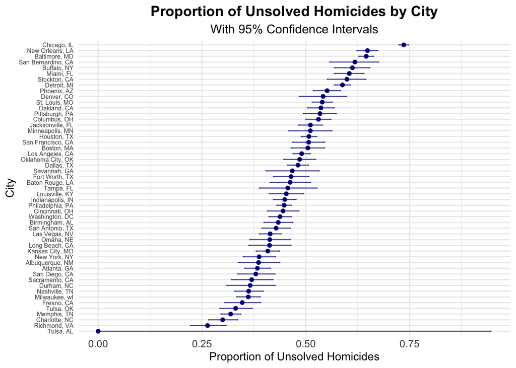

```r
# Step 6: Create plot showing estimates and CIs
homicide_plot <- city_tests %>%
  mutate(city_state = fct_reorder(city_state, proportion_unsolved)) %>%
  ggplot(aes(x = proportion_unsolved, y = city_state)) +
  geom_point(color = "darkblue", size = 1.5) +
  geom_errorbarh(aes(xmin = conf_low, xmax = conf_high),
                 height = 0.2, color = "darkblue", alpha = 0.7) +
  labs(
    title = "Proportion of Unsolved Homicides by City",
    subtitle = "With 95% Confidence Intervals",
    x = "Proportion of Unsolved Homicides",
    y = "City"
  ) +
  theme_minimal() +
  theme(
    plot.title = element_text(hjust = 0.5, size = 14, face = "bold"),
    plot.subtitle = element_text(hjust = 0.5, size = 12),
    axis.text.y = element_text(size = 6),
    axis.text.x = element_text(size = 10)
  )

# Display the plot
print(homicide_plot)
```

```r
# Step 7: Additional summary statistics
cat("\nOverall summary statistics:\n")
```

```
##
## Overall summary statistics:
```

```r
cat("Total number of cities:", nrow(city_tests), "\n")
```

```
## Total number of cities: 51
```

```r
cat("Range of unsolved proportions:",
    round(min(city_tests$proportion_unsolved), 3), "-",
    round(max(city_tests$proportion_unsolved), 3), "\n")
```

```
## Range of unsolved proportions: 0 - 0.736
```

```r
cat("Median proportion unsolved:",
    round(median(city_tests$proportion_unsolved), 3), "\n")
```

```
## Median proportion unsolved: 0.457
```

```r
# Cities with highest and lowest unsolved rates
cat("\nCities with highest proportion of unsolved homicides:\n")
```

```
##
## Cities with highest proportion of unsolved homicides:
```

```r
city_tests %>%
  arrange(desc(proportion_unsolved)) %>%
  select(city_state, proportion_unsolved) %>%
  head(5) %>%
  print()
```

```
## # A tibble: 5 × 2
##   city_state         proportion_unsolved
##   <chr>                            <dbl>
## 1 Chicago, IL                      0.736
## 2 New Orleans, LA                  0.649
## 3 Baltimore, MD                    0.646
## 4 San Bernardino, CA               0.618
## 5 Buffalo, NY                      0.612
```

```r
cat("\nCities with lowest proportion of unsolved homicides:\n")
```

```
##
## Cities with lowest proportion of unsolved homicides:
```

```r
city_tests %>%
  arrange(proportion_unsolved) %>%
  select(city_state, proportion_unsolved) %>%
  head(5) %>%
  print()
```

```
## # A tibble: 5 × 2
##   city_state    proportion_unsolved
##   <chr>                       <dbl>
## 1 Tulsa, AL                   0
## 2 Richmond, VA                0.263
## 3 Charlotte, NC               0.300
## 4 Memphis, TN                 0.319
## 5 Tulsa, OK                   0.331
```

[output not shown]

### Raw Data Description:

- **52,179 homicide cases** across 50+ U.S. cities

**Disposition breakdown:** - Closed by arrest: 25,674 (49.2%) - Closed without arrest: 2,922 (5.6%) - Open/No arrest: 23,583 (45.2%)

### Key Findings:

**Baltimore, MD Analysis:**

- Total homicides: 2,827
- Unsolved homicides: 1,825
- **Estimated proportion unsolved: 0.646 (64.6%)**
- **95% CI: (0.628, 0.663)**

**City Comparisons:**

- **Highest unsolved rates:** Chicago, IL (73.6%), New Orleans, LA (64.9%), Baltimore, MD (64.6%)
- **Lowest unsolved rates:** Tulsa, AL (0%), Richmond, VA (26.3%), Charlotte, NC (30.0%)
- **Median unsolved rate:** 45.7% across all cities

### Plot Interpretation:

The plot successfully shows:

- Each city as a point with its estimated proportion of unsolved homicides
- Error bars representing 95% confidence intervals
- Cities ordered from lowest to highest unsolved rates
- Clear visualization of the substantial variation across cities

The analysis reveals dramatic differences in homicide clearance rates across U.S. cities, with some cities solving less than 30% of homicides while others solve over 70%.